#### Step 3. Decide which variables to use for clustering

We base our choice of variables for the clustering on our factor analysis. Specifically, we chose one question - the one with the highest load - from each factor. In addition, we have added “Household Income” as a variable do be able to distinguish the clusters on their purchasing power.

Please recall that we chose 6 factors that together explain 55.84% of the variance in the data. By sorting each factor after load size we found the questions in the survey that relate to the different factors. Our factors suggested the following customer segments:

Factor 1: lifestyle-adventure driven customer that responds to the emotional aspects of owning a boat

Factor 2: expert user that focus on quality and technical features of the boat

Factor 3: conspicuous show-off consumer that mostly focus on the extent to which a particular type and brand of boat can increase his/her social status

Factor 4: brand-quality driven customer whose focus is on the cost/benefit of the functionality of the boat

Factor 5: rational-value conscious customer who is similar to segment 4 but that is less impressed by a brand but more focused on functionality

Factor 6: DIY customer who responds to the level of maintenance of the boat and the ease of repairability

#### Step 4. Define similarity or dissimilarity measures between observations

In our case we explore two distance metrics: the commonly used **Euclidean distance** as well as a simple one we define manually. Finally, we chose the **Euclidean distance**.

Pairwise Distances between the first 5 observations using The Euclidean Distance Metric

| 1 | 2 | 3 | 4 | 5 |
| --- | --- | --- | --- | --- |
| 0.0 |  |  |  |  |
| 2.4 | 0.0 |  |  |  |
| 2.4 | 2.0 | 0.0 |  |  |
| 3.2 | 2.0 | 3.2 | 0.0 |  |
| 3.5 | 2.4 | 3.7 | 2.8 | 0.0 |

Notice for example that if we use, say, the Manhattan distance metric, these distances change as follows:

Pairwise Distances between the first 5 observations using The Manhattan Distance Metric

| 1 | 2 | 3 | 4 | 5 |
| --- | --- | --- | --- | --- |
| 0.0 |  |  |  |  |
| 6.0 | 0.0 |  |  |  |
| 4.0 | 4.0 | 0.0 |  |  |
| 6.0 | 4.0 | 6.0 | 0.0 |  |
| 6.0 | 4.0 | 8.0 | 6.0 | 0.0 |

Let's now define our own distance metric, as an example. Let's say that the management team of the company believes that two customers are similar if they do not differ in their ratings of the attitudinal questions by more than 2 points. We can manually assign a distance of 1 for every question for which two customers gave an answer that differs by more than 2 points, and 0 otherwise. It is easy to write this distance function in R:

```r
My_Distance_function <- function(x, y) {
    sum(abs(x - y) > 2)
}
```

Here is how the pairwise distances between the respondents now look like.

Pairwise Distances between the first 5 observations using a simple manually defined Distance Metric

| 1 | 2 | 3 | 4 | 5 |
| --- | --- | --- | --- | --- |
| 0.0 |  |  |  |  |
| 0.0 | 0.0 |  |  |  |
| 0.0 | 0.0 | 0.0 |  |  |
| 0.0 | 0.0 | 0.0 | 0.0 |  |
| 1.0 | 0.0 | 1.0 | 0.0 | 0.0 |

#### Step 5. Visualize Individual Attributes and Pair-wise Distances between the Observations

or the histogram of all pairwise distances for the euclidean distance:

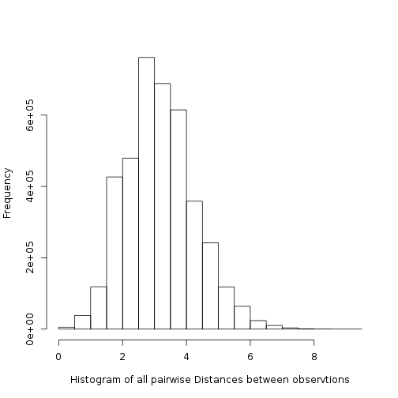

> Visualization is very important for data analytics, as it can provide a first understanding of the data.